# writeup

The median is an important quantity in data analysis. It represents the middle value of the data distribution. Estimates of the median, however, have a degree of uncertainty because (a) the estimates are calculated from a finite sample and (b) the data distribution of the underlying data is generally unknown. One important roles of a data scientist is to quantify and to communicate the degree of uncertainty in his or her data analysis.

```r
library(tidyverse)
library(dplyr)
```

In this blog, we will use standard normal distribtution to demonstrate order statistic. The stadard normal distribution has a mean=0 and standard deviation = 1

Begin with the median from a sample of N = 200 from the standard normal distribution. Write an R function that is the density function for the median in this sample. Note that the 100th order statistic is approximately the median, and use the order statistic formula discussed in class. Generate a plot of the function.

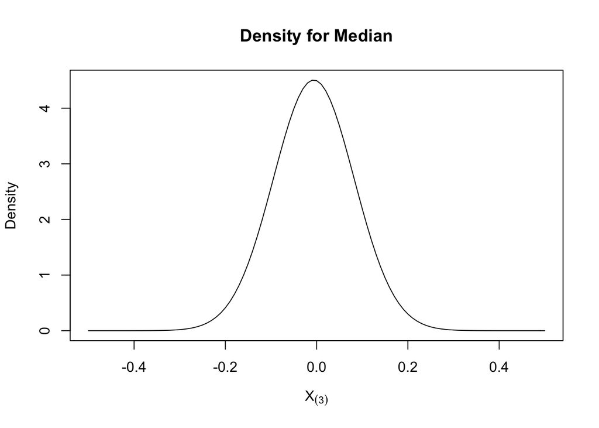

```r
dorder <- function(x){
  100*
  choose(200,100)*
  (pnorm(x))^(100-1)*
  (1-pnorm(x))^(200-100)*
  dnorm(x)
}
curve(
    dorder(x)
  , -0.5
  , 0.5
  , xlab = parse(text="X[(3)]")
  , ylab = "Density"
  , main="Density for Median"
)
```

above is the graph of median distribution in PDF. We can see that the graph is systematical with center at 0.

Q: Write an R function that is the probability function for the median in this sample. Use the order statistic formula discussed in class. Generate a plot of the function.

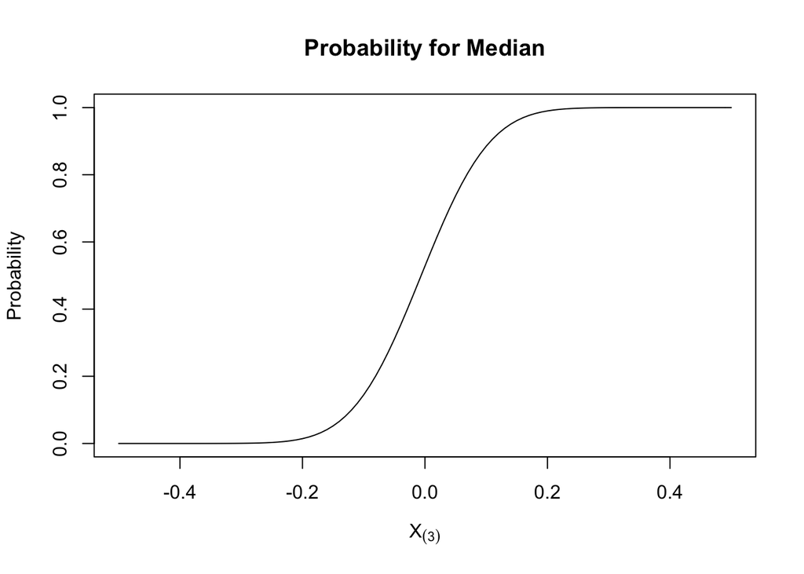

```r
porder <- function(x){
  pbinom(100-1, 200, pnorm(x), lower.tail = FALSE)
}
curve(
    porder(x)
  , -0.5
  , 0.5
  , xlab = parse(text="X[(3)]")
  , ylab = "Probability"
  , main="Probability for Median"
)
```

above is the CDF of median distribtuion.

Q: Write an R function that is the quantile function for the median in this sample. (You have several options for how to write this function.) Generate a plot of the function.

```r
data <- data.frame(x=seq(-0.5,0.5,by=0.001)) %>%
  mutate(p=porder(x))
qf1 <- approxfun(data$p,data$x)
qf1(0.7)
```

```
## [1] 0.04016003
```

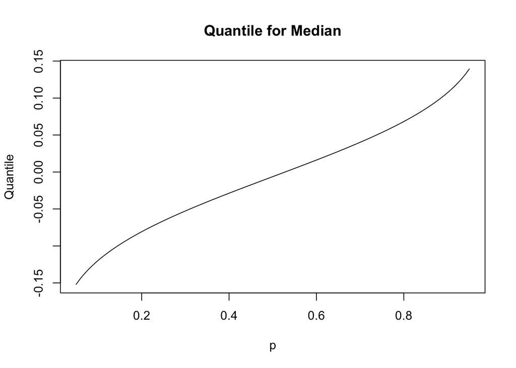

```r
curve(qf1,0.05,0.95,, main="Quantile for Median",xlab = "p",ylab = "Quantile")
```

This is the graph of quantile function for median. In this problem, I selected lookup table as the solution.

Q: Simulate the sampling distribution for the median. Create a plot of the empirical CDF (ECDF). Overlay the plot of the ECDF with a plot of the CDF.

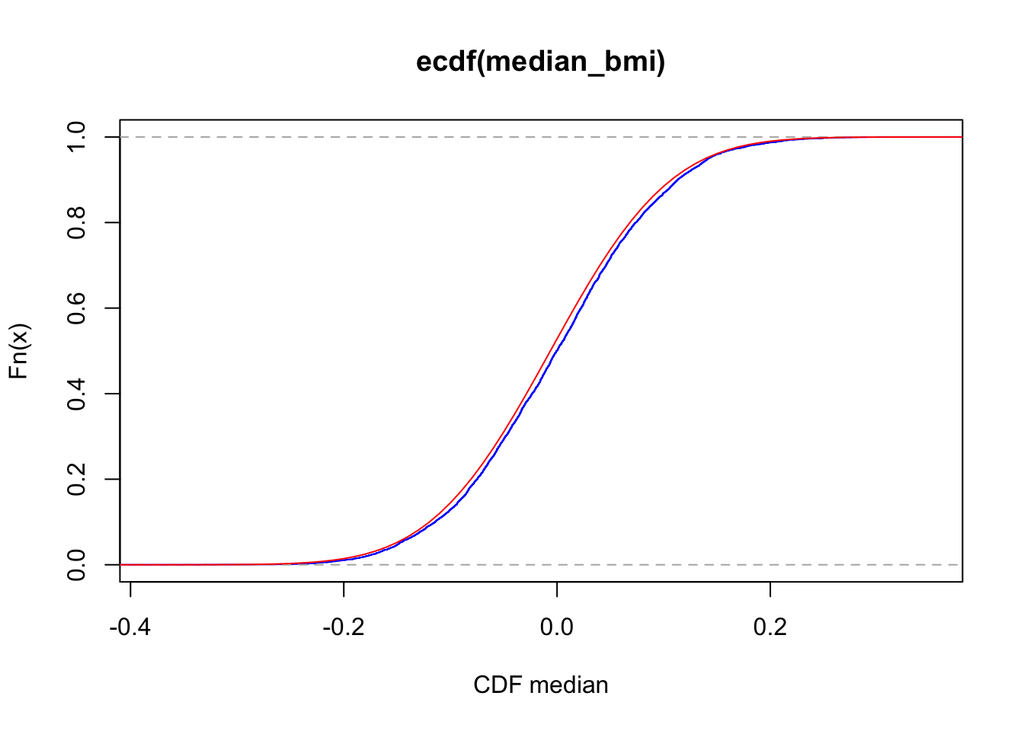

```r
median_bmi <- rep(NA, 5000)
for(i in seq_along(median_bmi)){
  bmi <- rnorm(200)
  median_bmi[i] <- median(bmi)
}
plot(ecdf(median_bmi),xlab = parse(text = "CDF~median"),col="blue")
curve(porder(x),-0.5,0.5,add = TRUE, col="red")
```

the graph above is the graph of simulated ecdf overlay on cdf. the simulation has 5000 trails with size of 200 each. We can see that the simulated result is similar to the cdf, but in the middle there are some miss matching.

Q: Using the simulated sampling distribution from the previous question, create a histogram (on the density scale). Overlay the histogram with a plot of the density function.

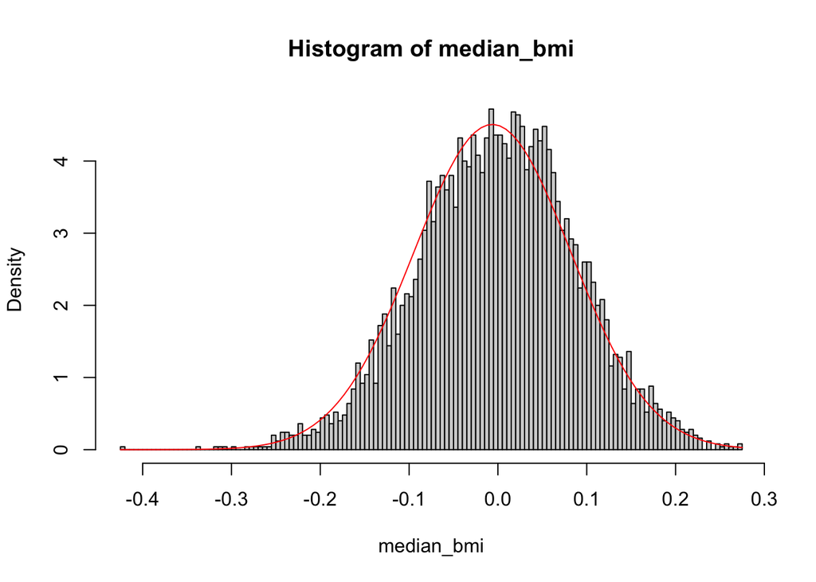

```r
median_bmi <- rep(NA, 5000)
for(i in seq_along(median_bmi)){
  bmi <- rnorm(200)
  median_bmi[i] <- median(bmi)
}
hist(median_bmi,breaks = 100,freq = FALSE)
curve(dorder(x),add = TRUE,col="red")
```

similar to the previous simulation, instead of cdf, this is the pdf overlay on the histogram. We can see that the simulation has a good fit with the theoritcal value.

Q: One very common way to compare a random sample to a theoretical candidate distribution is the QQ plot. It is created by ploting quantiles of the theoretical distribution on the x-axis and empirical quantiles from the sample on the y-axis.

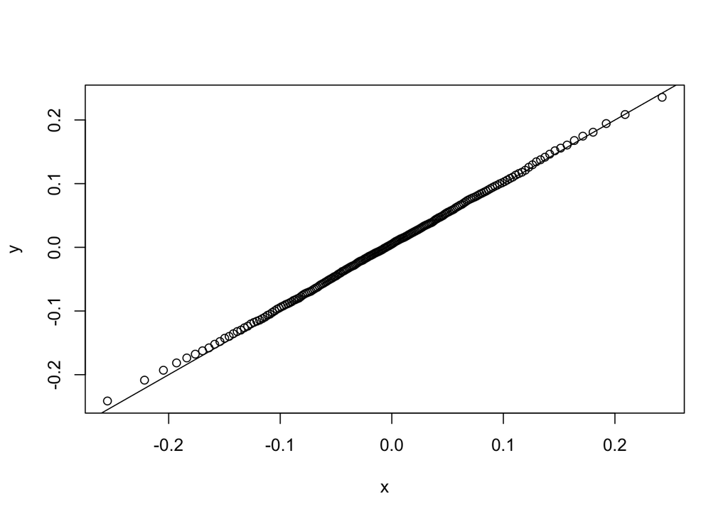

```r
p <-ppoints(200)
median_bmi <- rep(NA, 5000)
for(i in seq_along(median_bmi)){
  bmi <- rnorm(200)
  median_bmi[i] <- median(bmi)
}

x<-qf1(p)
y<-quantile(median_bmi,probs = p)
plot(x,y)
abline(0,1)
```

This is the qqplot. the x axis is the theoritcal value from the lookup table, the y axis is the simulated quantiels. The qq plot is close to the line y=x, which means the simulation result is similar to the lookup table.

Q: Modify the dorder, porder, and qorder functions so that the functions take a new parameter k (for the kt**h order statistic) so that the functions will work for any order statistic and not just the median.

```r
dorder <- function(x,k){
  k*
  choose(200,k)*
  (pnorm(x))^(k-1)*
  (1-pnorm(x))^(200-k)*
  dnorm(x)
}
```

```r
porder <- function(x,k){
  pbinom(k-1, 200, pnorm(x), lower.tail = FALSE)
}
```

```r
qorder <- function(p,k) {
  tmp <- function(x,k){porder(x,k)-p}
  out<-p*0
  for (i in seq_along(p)) {
    out[i] <- uniroot(tmp,c(-5,10),p=p[i])$root

  }
  out
}
```

each of the function is modefited. the parameter k is added. We can simply replace the 100 in previous problem to k, so that we can find the desired order statistic. However, it is hard to adjust the lookup table, I used uniroot instead.

Q: Generate the QQ plot for simulated data from the sampling distribution of the sample max and the theoretical largest order statistic distribution.

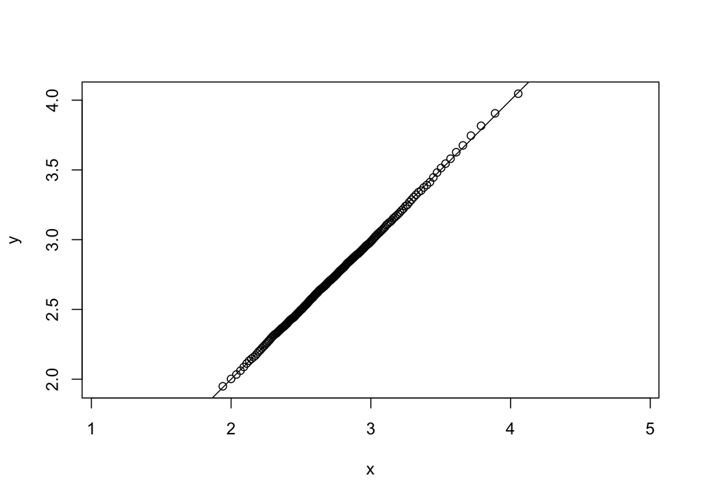

```r
M <- 5000 # studies
N <- 200 # sample size
b <- array(rnorm(M*N), c(M, N))
max <- b %>% apply(1, function(x){sort(x)[200]})

qmax <- function(p) {
  tmp <- function(x,p){porder(x,200)-p}
  out<-p*0
  for (i in seq_along(p)) {
    out[i] <- uniroot(tmp,c(-5,10),p=p[i])$root

  }
  out
}

x<-qmax((1:199)/200)
y <- quantile(max, probs = (1:199)/200,na.rm = TRUE)
#rg <- range(x, y, na.rm=T)
qqplot(x,y,asp=1)
abline(0,1)
```

```r
#plot(x,y)
```

this i sthe qq plot for maximum. We can simply select 200 as our desired k value. The simulation result is a good fit to our theoritcal result.

Q: Modify the dorder, porder, and qorder functions so that the functions take new parameters dist and … so that the functions will work for any continuous distribution that has d and p functions defined in R.

```r
dorder <- function(x,k,n,dist,...){
  pf <- eval(parse(text=paste0("p" ,dist)))
  df <- eval(parse(text=paste0("d" , dist)))
  k*
    choose(n,k)*
    (pf(x, ...))^(k-1)*
    (1-pf(x, ...))^(n-k)*
    df(x, ...)
}

porder <- function(x,k,n,dist,...){
  pf <- eval(parse(text=paste0("p" ,dist)))
  pbinom(k-1, n, pf(x,...), lower.tail = FALSE)
}

qorder <- function(p,k,dist,...) {
  tmp <- function(x,p){porder(x,k,dist,...)-p}
  out<-p*0
  for (i in seq_along(p)) {
    out[i] <- uniroot(tmp,c(-100,100),p=p[i])$root

  }
  out
}
```

the defined function is modiefied again, dist and … is added to the function.

Q: Use the newly modified functions to plot the probability and density functions for the sample min (N = 200).

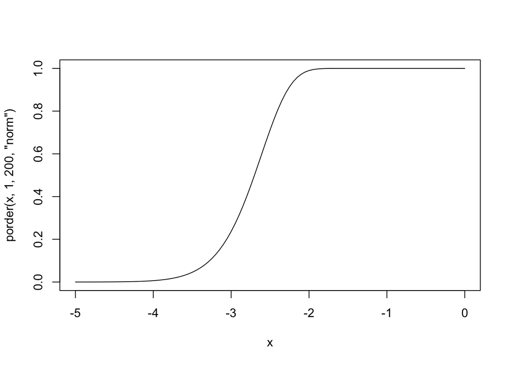

```r
curve(porder(x, 1, 200, "norm"), -5, 0)
```

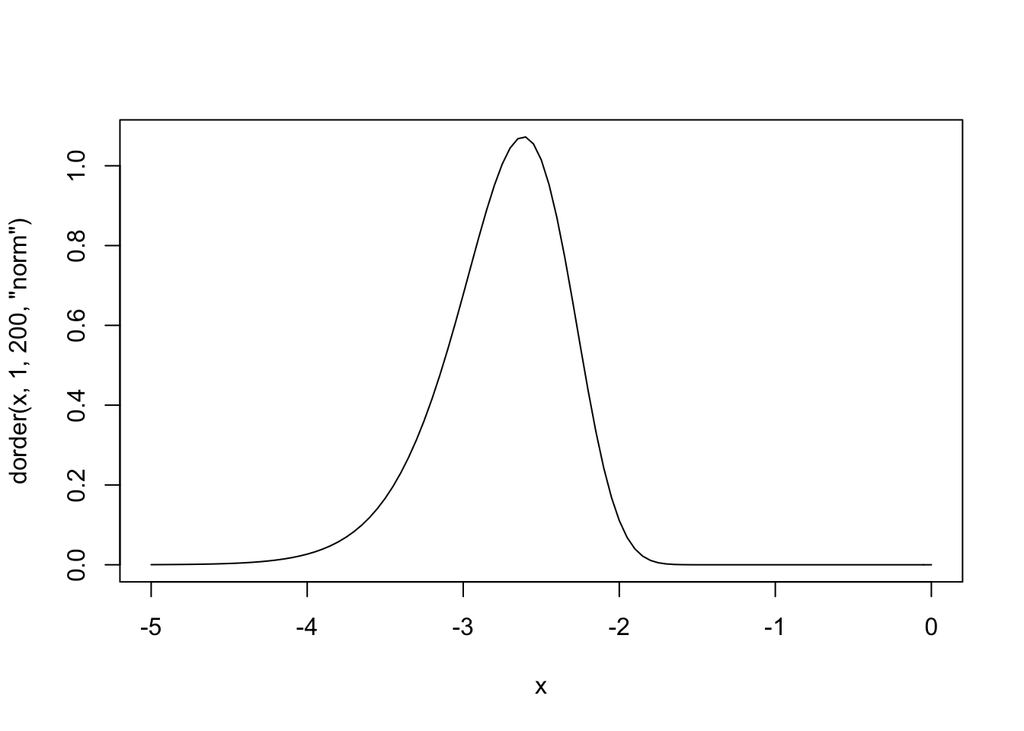

```r
curve(dorder(x, 1, 200, "norm"), -5, 0)
```

The above graph shows the pdf and vdf for x(min).